# IP_WEEK_14_DIMENSIONALITY_REDUCTION

Nathan_Njonge

7/17/2021

## PROBLEM DEFINITION

You are a Data analyst at Carrefour Kenya and are currently undertaking a project that will inform the marketing department on the most relevant marketing strategies that will result in the highest no. of sales (total price including tax). Your project has been divided into four parts where you’ll explore a recent marketing dataset by performing various unsupervised learning techniques and later providing recommendations based on your insights.

```r
# load our dataset
dataset <- read.csv("http://bit.ly/CarreFourDataset")
```

```r
# preview the top of our dataset
head(dataset)
```

```
##    Invoice.ID Branch Customer.type Gender           Product.line Unit.price
## 1 750-67-8428      A        Member Female      Health and beauty      74.69
## 2 226-31-3081      C        Normal Female Electronic accessories      15.28
## 3 631-41-3108      A        Normal   Male     Home and lifestyle      46.33
## 4 123-19-1176      A        Member   Male      Health and beauty      58.22
## 5 373-73-7910      A        Normal   Male      Sports and travel      86.31
## 6 699-14-3026      C        Normal   Male Electronic accessories      85.39
##   Quantity     Tax      Date  Time     Payment   cogs gross.margin.percentage
## 1        7 26.1415  1/5/2019 13:08     Ewallet 522.83                4.761905
## 2        5  3.8200  3/8/2019 10:29        Cash  76.40                4.761905
## 3        7 16.2155  3/3/2019 13:23 Credit card 324.31                4.761905
## 4        8 23.2880 1/27/2019 20:33     Ewallet 465.76                4.761905
## 5        7 30.2085  2/8/2019 10:37     Ewallet 604.17                4.761905
## 6        7 29.8865 3/25/2019 18:30     Ewallet 597.73                4.761905
##   gross.income Rating    Total
## 1      26.1415    9.1 548.9715
## 2       3.8200    9.6  80.2200
## 3      16.2155    7.4 340.5255
## 4      23.2880    8.4 489.0480
## 5      30.2085    5.3 634.3785
## 6      29.8865    4.1 627.6165
```

```r
# preview the bottom of our dataset
tail(dataset)
```

```
##       Invoice.ID Branch Customer.type Gender           Product.line Unit.price
## 995  652-49-6720      C        Member Female Electronic accessories      60.95
## 996  233-67-5758      C        Normal   Male      Health and beauty      40.35
## 997  303-96-2227      B        Normal Female     Home and lifestyle      97.38
## 998  727-02-1313      A        Member   Male     Food and beverages      31.84
## 999  347-56-2442      A        Normal   Male     Home and lifestyle      65.82
## 1000 849-09-3807      A        Member Female    Fashion accessories      88.34
##      Quantity     Tax      Date  Time Payment   cogs gross.margin.percentage
## 995         1  3.0475 2/18/2019 11:40 Ewallet  60.95                4.761905
## 996         1  2.0175 1/29/2019 13:46 Ewallet  40.35                4.761905
## 997        10 48.6900  3/2/2019 17:16 Ewallet 973.80                4.761905
## 998         1  1.5920  2/9/2019 13:22    Cash  31.84                4.761905
## 999         1  3.2910 2/22/2019 15:33    Cash  65.82                4.761905
## 1000        7 30.9190 2/18/2019 13:28    Cash 618.38                4.761905
##      gross.income Rating     Total
## 995        3.0475    5.9   63.9975
## 996        2.0175    6.2   42.3675
## 997       48.6900    4.4 1022.4900
## 998        1.5920    7.7   33.4320
## 999        3.2910    4.1   69.1110
## 1000      30.9190    6.6  649.2990
```

```r
# view the number of columns and rows
dim(dataset)
```

```
## [1] 1000   16
```

> Our dataset has 1000 rows and 16 columns.

```r
# view the datatypes of our columns
str(dataset)
```

```
## 'data.frame':    1000 obs. of  16 variables:
##  $ Invoice.ID             : chr  "750-67-8428" "226-31-3081" "631-41-3108" "123-19-1176" ...
##  $ Branch                 : chr  "A" "C" "A" "A" ...
##  $ Customer.type          : chr  "Member" "Normal" "Normal" "Member" ...
##  $ Gender                 : chr  "Female" "Female" "Male" "Male" ...
##  $ Product.line           : chr  "Health and beauty" "Electronic accessories" "Home and lifestyle" "Health and beauty" ...
##  $ Unit.price             : num  74.7 15.3 46.3 58.2 86.3 ...
##  $ Quantity               : int  7 5 7 8 7 7 6 10 2 3 ...
##  $ Tax                    : num  26.14 3.82 16.22 23.29 30.21 ...
##  $ Date                   : chr  "1/5/2019" "3/8/2019" "3/3/2019" "1/27/2019" ...
##  $ Time                   : chr  "13:08" "10:29" "13:23" "20:33" ...
##  $ Payment                : chr  "Ewallet" "Cash" "Credit card" "Ewallet" ...
##  $ cogs                   : num  522.8 76.4 324.3 465.8 604.2 ...
##  $ gross.margin.percentage: num  4.76 4.76 4.76 4.76 4.76 ...
##  $ gross.income           : num  26.14 3.82 16.22 23.29 30.21 ...
##  $ Rating                 : num  9.1 9.6 7.4 8.4 5.3 4.1 5.8 8 7.2 5.9 ...
##  $ Total                  : num  549 80.2 340.5 489 634.4 ...
```

```r
# check total missing values in the columns
colSums(is.na(dataset))
```

```
##              Invoice.ID                  Branch           Customer.type
##                       0                       0                       0
##                  Gender            Product.line              Unit.price
##                       0                       0                       0
##                Quantity                     Tax                    Date
##                       0                       0                       0
##                    Time                 Payment                    cogs
##                       0                       0                       0
## gross.margin.percentage            gross.income                  Rating
##                       0                       0                       0
##                   Total
##                       0
```

> There is no missing data in our columns.

```r
# find any duplicated rows in our dataset
duplicated_rows <- dataset[duplicated(dataset),]
duplicated_rows
```

```
##  [1] Invoice.ID              Branch                  Customer.type
##  [4] Gender                  Product.line            Unit.price
##  [7] Quantity                Tax                     Date
## [10] Time                    Payment                 cogs
## [13] gross.margin.percentage gross.income            Rating
## [16] Total
## <0 rows> (or 0-length row.names)
```

> There appears to be no duplicated entries in our data.

# Handling outliers

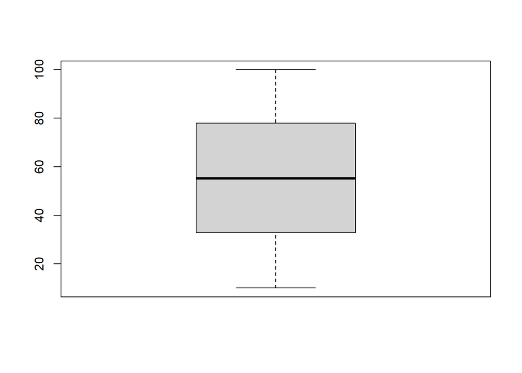

```r
# checking for outliers on the Unit.price  column
boxplot(dataset$Unit.price)
```

```r
boxplot.stats(dataset$Unit.price)$out
```

```
## numeric(0)
```

> There is no presence of outliers in the Unit price column.

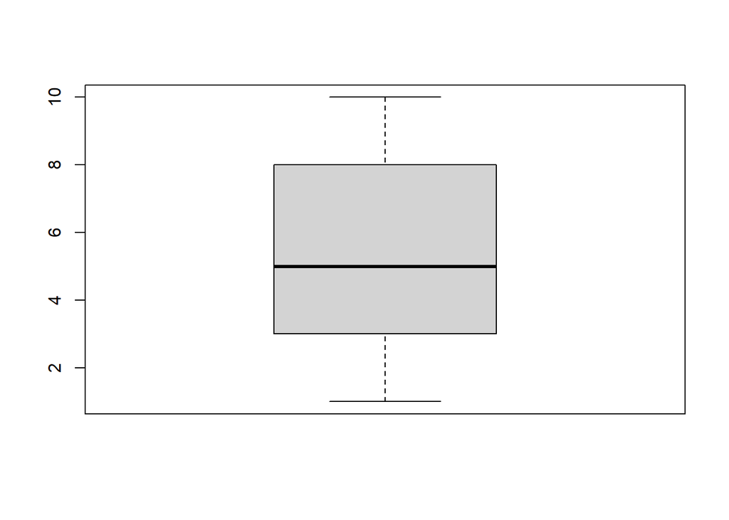

```r
# checking for outliers on the Quantity column
boxplot(dataset$Quantity)
```

```r
boxplot.stats(dataset$Quantity)$out
```

```
## integer(0)
```

> There appears to be no outliers in the quantity column.

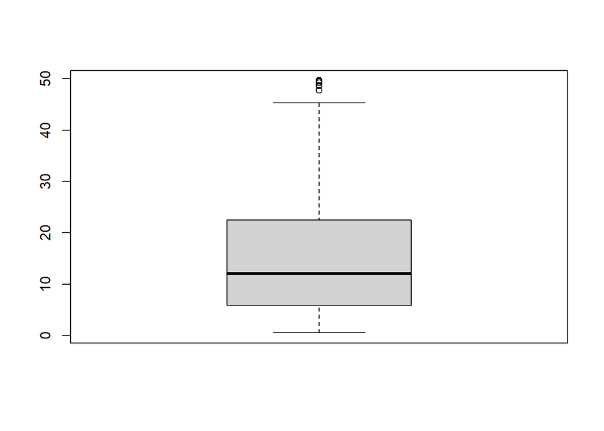

```r
# checking for outliers on the Tax column
boxplot(dataset$Tax)
```

```r
boxplot.stats(dataset$Tax)$out
```

```
## [1] 47.790 49.490 49.650 47.720 48.605 49.260 48.750 48.685 48.690
```

> The outliers in the Tax column are as a result of the products that are taxed highly.

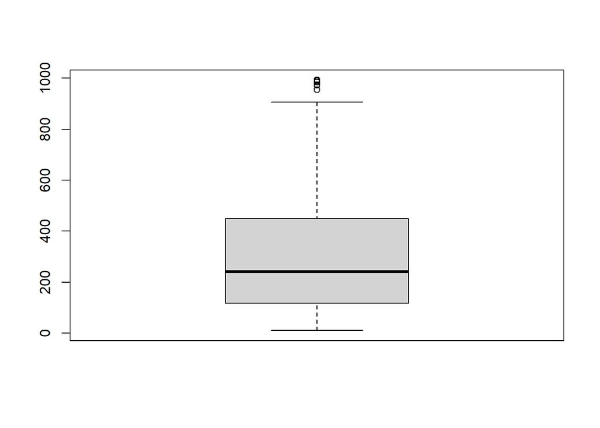

```r
# checking for outliers on the cogs column
boxplot(dataset$cogs)
```

```r
boxplot.stats(dataset$cogs)$out
```

```
## [1] 955.8 989.8 993.0 954.4 972.1 985.2 975.0 973.7 973.8
```

> The outliers in the cogs column are as a result of the high cost of goods sold.

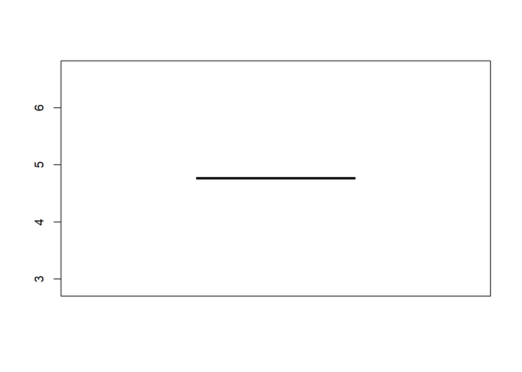

```r
# checking for outliers on the gross.margin.percentage column
boxplot(dataset$gross.margin.percentage)
```

```r
boxplot.stats(dataset$gross.margin.percentage)$out
```

```
## numeric(0)
```

> There appears to be no outliers in the gross.margin.percentage column.

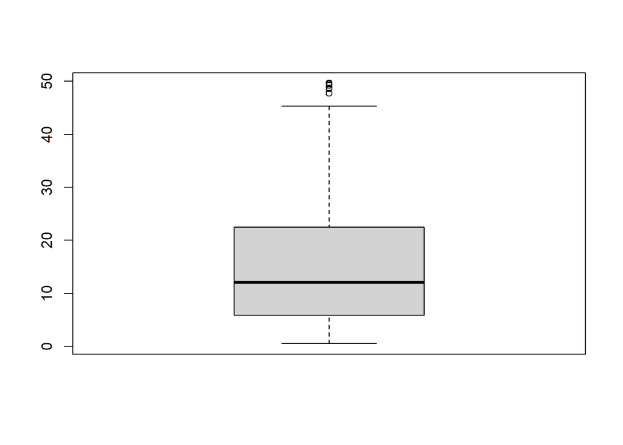

```r
# checking for outliers on the gross.income column
boxplot(dataset$gross.income)
```

```r
boxplot.stats(dataset$gross.income)$out
```

```
## [1] 47.790 49.490 49.650 47.720 48.605 49.260 48.750 48.685 48.690
```

> The outliers on the gross income column are as a result of the high gross income.

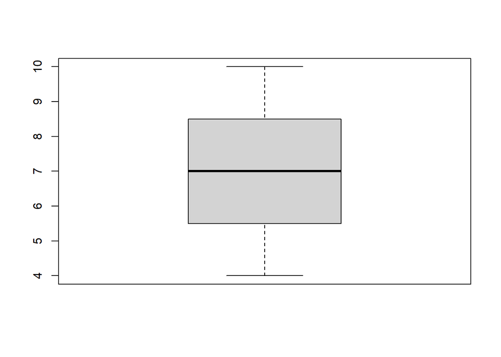

```r
# checking for outliers on the Rating column
boxplot(dataset$Rating)
```

```r
boxplot.stats(dataset$Rating)$out
```

```
## numeric(0)
```

> There is no presence of outliers in the Rating Column.

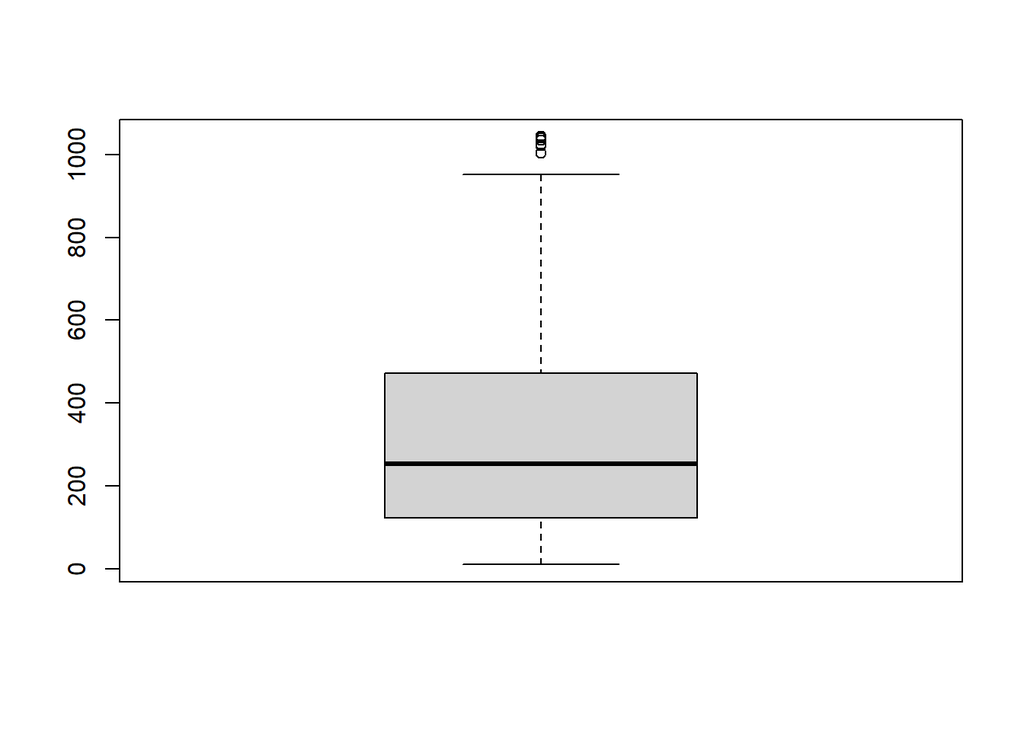

```r
# checking for outliers on the Total column
boxplot(dataset$Total)
```

```r
boxplot.stats(dataset$Total)$out
```

```
## [1] 1003.590 1039.290 1042.650 1002.120 1020.705 1034.460 1023.750 1022.385
## [9] 1022.490
```

> The outliers in the total Column are as a result of the high total amount.

# Exploratory Data Analysis

## Univariate Analysis

### 1.Measures of Central Tendency & Measures of Dispersion

```r
summary(dataset)
```

```
##   Invoice.ID           Branch          Customer.type         Gender
##  Length:1000        Length:1000        Length:1000        Length:1000
##  Class :character   Class :character   Class :character   Class :character
##  Mode  :character   Mode  :character   Mode  :character   Mode  :character
##
##
##
##  Product.line         Unit.price       Quantity          Tax
##  Length:1000        Min.   :10.08   Min.   : 1.00   Min.   : 0.5085
##  Class :character   1st Qu.:32.88   1st Qu.: 3.00   1st Qu.: 5.9249
##  Mode  :character   Median :55.23   Median : 5.00   Median :12.0880
##                     Mean   :55.67   Mean   : 5.51   Mean   :15.3794
##                     3rd Qu.:77.94   3rd Qu.: 8.00   3rd Qu.:22.4453
##                     Max.   :99.96   Max.   :10.00   Max.   :49.6500
##      Date               Time             Payment               cogs
##  Length:1000        Length:1000        Length:1000        Min.   : 10.17
##  Class :character   Class :character   Class :character   1st Qu.:118.50
##  Mode  :character   Mode  :character   Mode  :character   Median :241.76
##                                                           Mean   :307.59
##                                                           3rd Qu.:448.90
##                                                           Max.   :993.00
##  gross.margin.percentage  gross.income         Rating           Total
##  Min.   :4.762           Min.   : 0.5085   Min.   : 4.000   Min.   :  10.68
##  1st Qu.:4.762           1st Qu.: 5.9249   1st Qu.: 5.500   1st Qu.: 124.42
##  Median :4.762           Median :12.0880   Median : 7.000   Median : 253.85
##  Mean   :4.762           Mean   :15.3794   Mean   : 6.973   Mean   : 322.97
##  3rd Qu.:4.762           3rd Qu.:22.4453   3rd Qu.: 8.500   3rd Qu.: 471.35
##  Max.   :4.762           Max.   :49.6500   Max.   :10.000   Max.   :1042.65
```

```r
# mode function
getmode <- function(v) {
   uniqv <- unique(v)
   uniqv[which.max(tabulate(match(v, uniqv)))]
}
```

```r
#  mode of numerical columns
library(dplyr)
dataset %>% summarize_if(is.numeric, getmode)
```

```
##   Unit.price Quantity   Tax  cogs gross.margin.percentage gross.income Rating
## 1      83.77       10 39.48 789.6                4.761905        39.48      6
##    Total
## 1 829.08
```

```r
# range of numerical columns
dataset %>% summarize_if(is.numeric, range)
```

```
##   Unit.price Quantity     Tax   cogs gross.margin.percentage gross.income
## 1      10.08        1  0.5085  10.17                4.761905       0.5085
## 2      99.96       10 49.6500 993.00                4.761905      49.6500
##   Rating     Total
## 1      4   10.6785
## 2     10 1042.6500
```

```r
# Quantile of numerical columns
dataset %>% summarize_if(is.numeric, quantile)
```

```
##   Unit.price Quantity       Tax     cogs gross.margin.percentage gross.income
## 1     10.080        1  0.508500  10.1700                4.761905     0.508500
## 2     32.875        3  5.924875 118.4975                4.761905     5.924875
## 3     55.230        5 12.088000 241.7600                4.761905    12.088000
## 4     77.935        8 22.445250 448.9050                4.761905    22.445250
## 5     99.960       10 49.650000 993.0000                4.761905    49.650000
##   Rating     Total
## 1    4.0   10.6785
## 2    5.5  124.4224
## 3    7.0  253.8480
## 4    8.5  471.3502
## 5   10.0 1042.6500
```

```r
# Variance of numerical columns
dataset %>% summarize_if(is.numeric, var)
```

```
##   Unit.price Quantity      Tax     cogs gross.margin.percentage gross.income
## 1   701.9653 8.546446 137.0966 54838.64                       0     137.0966
##     Rating   Total
## 1 2.953518 60459.6
```

```r
# Standard Deviation of numerical columns
dataset %>% summarize_if(is.numeric, sd)
```

```
##   Unit.price Quantity      Tax     cogs gross.margin.percentage gross.income
## 1   26.49463 2.923431 11.70883 234.1765                       0     11.70883
##    Rating    Total
## 1 1.71858 245.8853
```

### Univariate Graphical

#### BarGraph

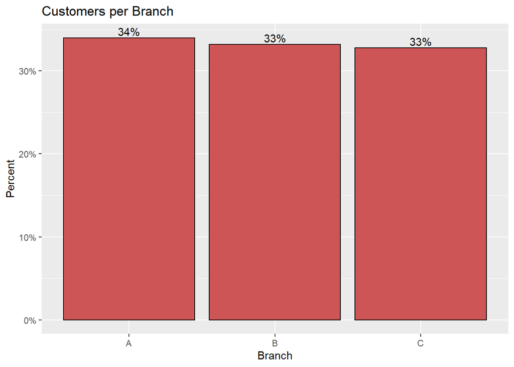

```r
library(scales)
library(ggplot2)
plotdata <- dataset %>%
  count(Branch) %>%
  mutate(pct = n / sum(n),
         pctlabel = paste0(round(pct*100), "%"))

# plot the bars as percentages,
# in decending order with bar labels
ggplot(plotdata,
       aes(x = reorder(Branch, -pct),
           y = pct)) +
  geom_bar(stat = "identity",
           fill = "indianred3",
           color = "black") +
  geom_text(aes(label = pctlabel),
            vjust = -0.25) +
  scale_y_continuous(labels = percent) +
  labs(x = "Branch",
       y = "Percent",
       title  = "Customers per Branch")
```

> The customers for Branch A were 1% higher compared to branch B and C.

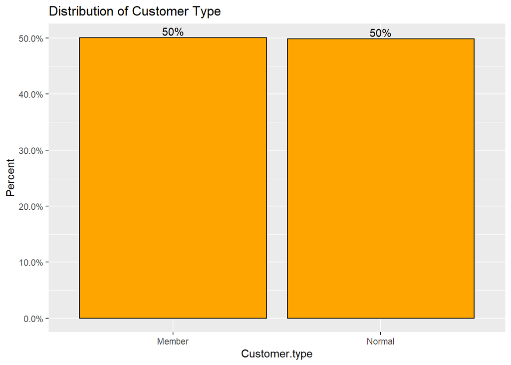

```r
# Barchart of Customer Type
plotdata <- dataset %>%
  count(Customer.type) %>%
  mutate(pct = n / sum(n),
         pctlabel = paste0(round(pct*100), "%"))

# plot the bars as percentages,
# in decending order with bar labels
ggplot(plotdata,
       aes(x = reorder(Customer.type, -pct),
           y = pct)) +
  geom_bar(stat = "identity",
           fill = "orange",
           color = "black") +
  geom_text(aes(label = pctlabel),
            vjust = -0.25) +
  scale_y_continuous(labels = percent) +
  labs(x = "Customer.type",
       y = "Percent",
       title  = "Distribution of Customer Type")
```

> The customer type distribution was equal at 50% for the Member Customers and Normal Customers.

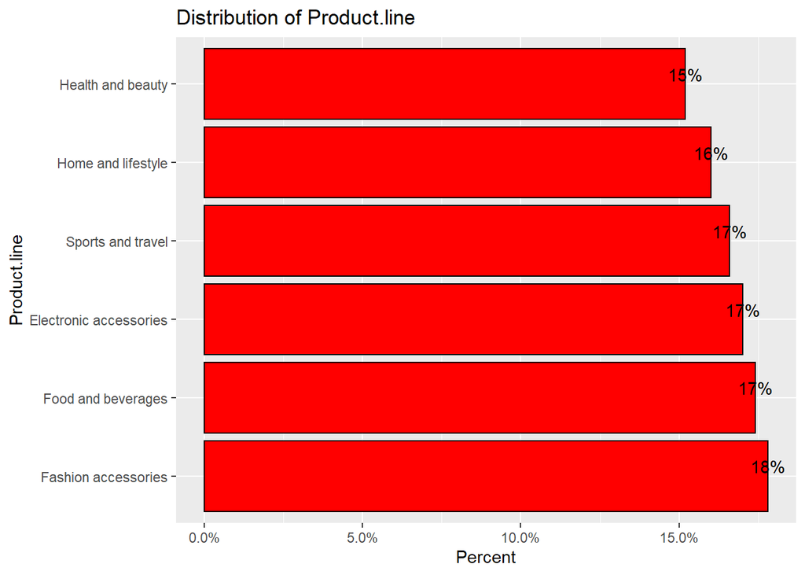

```r
# Barchart of Product Line
plotdata <- dataset %>%
  count(Product.line) %>%
  mutate(pct = n / sum(n),
         pctlabel = paste0(round(pct*100), "%"))

# plot the bars as percentages,
# in decending order with bar labels
ggplot(plotdata,
       aes(x = reorder(Product.line, -pct),
           y = pct)) +
  geom_bar(stat = "identity",
           fill = "red",
           color = "black") +
  geom_text(aes(label = pctlabel),
            vjust = -0.25) +
  scale_y_continuous(labels = percent) +
  labs(x = "Product.line",
       y = "Percent",
       title  = "Distribution of Product.line") +
  coord_flip()
```

> Fashion accessories had a higher distribution at 18% while Health and Beauty had a lower distribution at 15%.

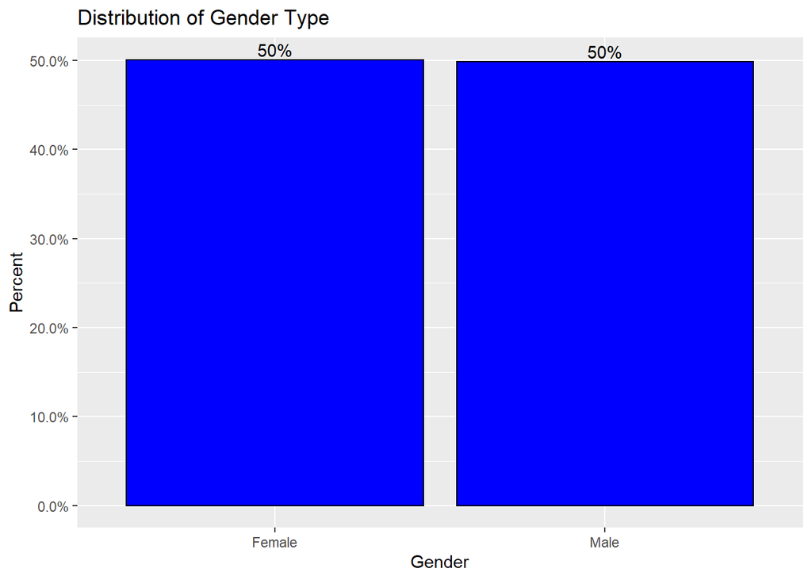

```r
# Barchart of Gender Distribution
plotdata <- dataset %>%
  count(Gender) %>%
  mutate(pct = n / sum(n),
         pctlabel = paste0(round(pct*100), "%"))

# plot the bars as percentages,
# in decending order with bar labels
ggplot(plotdata,
       aes(x = reorder(Gender, -pct),
           y = pct)) +
  geom_bar(stat = "identity",
           fill = "blue",
           color = "black") +
  geom_text(aes(label = pctlabel),
            vjust = -0.25) +
  scale_y_continuous(labels = percent) +
  labs(x = "Gender",
       y = "Percent",
       title  = "Distribution of Gender Type")
```

> From our barchart there appears to be an even distribution of Males and Females.

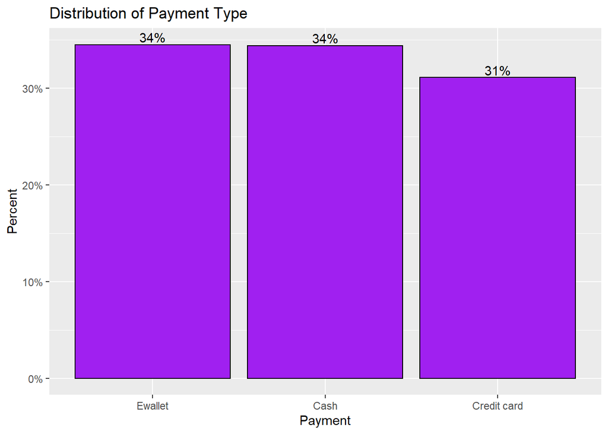

```r
# Barchart of Payment Distribution
plotdata <- dataset %>%
  count(Payment) %>%
  mutate(pct = n / sum(n),
         pctlabel = paste0(round(pct*100), "%"))

# plot the bars as percentages,
# in decending order with bar labels
ggplot(plotdata,
       aes(x = reorder(Payment, -pct),
           y = pct)) +
  geom_bar(stat = "identity",
           fill = "purple",
           color = "black") +
  geom_text(aes(label = pctlabel),
            vjust = -0.25) +
  scale_y_continuous(labels = percent) +
  labs(x = "Payment",
       y = "Percent",
       title  = "Distribution of Payment Type")
```

> From our barchart the most common payment type is Ewallet and Cash Payment type the least is Credit card.

## Histogram

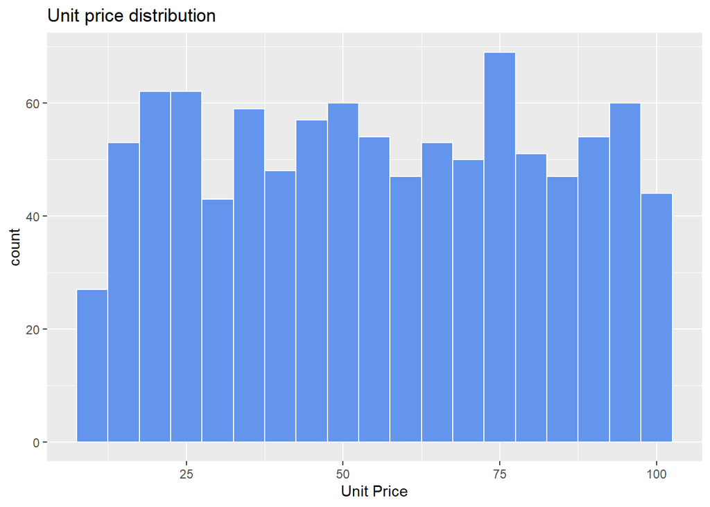

```r
# plot the histogram of Unit.price
ggplot(dataset, aes(x = Unit.price)) +
  geom_histogram(fill = "cornflowerblue",
                 color = "white",
                 binwidth = 5) +
  labs(title="Unit price distribution",
       x = "Unit Price")
```

> From our histogram we can see that the unit price of 75 had among the highest count.

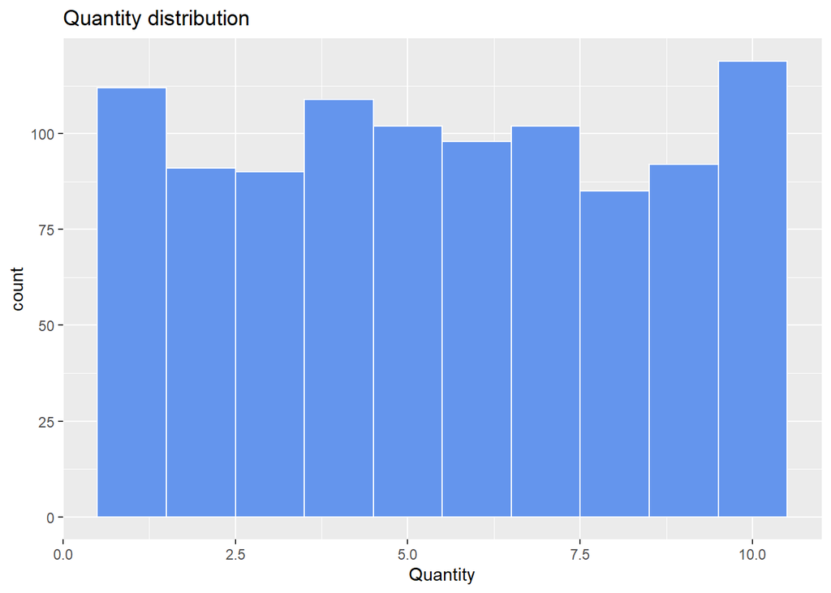

```r
# plot the histogram of Quantity
ggplot(dataset, aes(x = Quantity)) +
  geom_histogram(fill = "cornflowerblue",
                 color = "white",
                 binwidth = 1) +
  labs(title="Quantity distribution",
       x = "Quantity")
```

> From our histogram of Quantity distribution the quantity of 10 had the highest count.

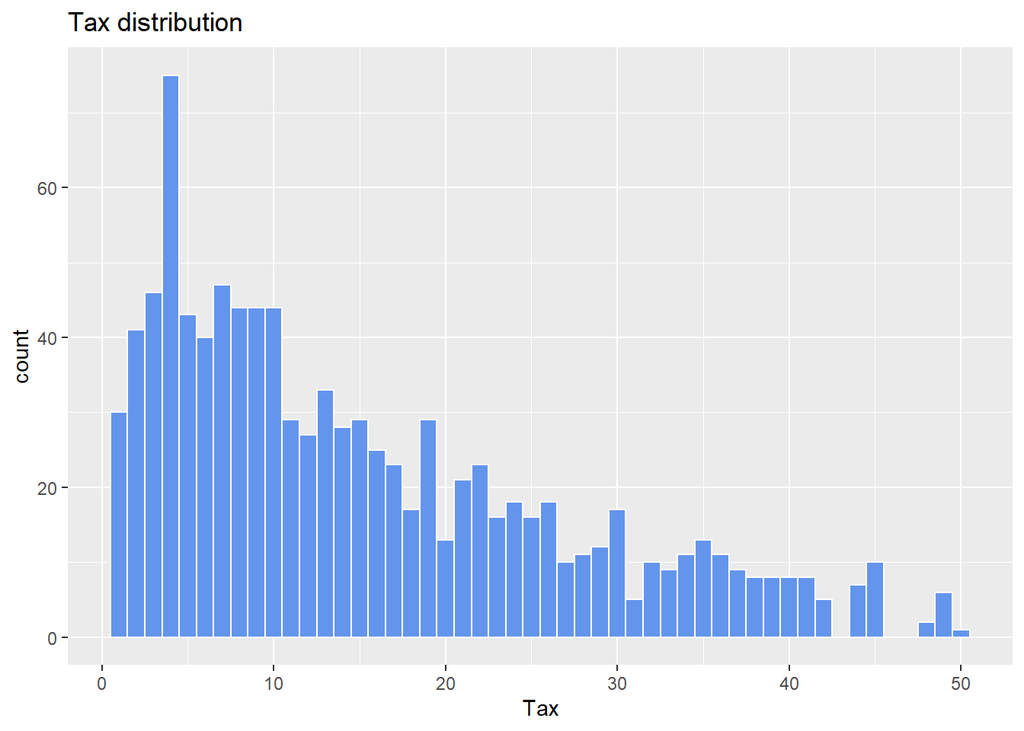

```r
# plot the histogram of Tax
ggplot(dataset, aes(x = Tax)) +
  geom_histogram(fill = "cornflowerblue",
                 color = "white",
                 binwidth = 1) +
  labs(title="Tax distribution",
       x = "Tax")
```

> From our histogram tax rates between 0 and 10 had the highest count.

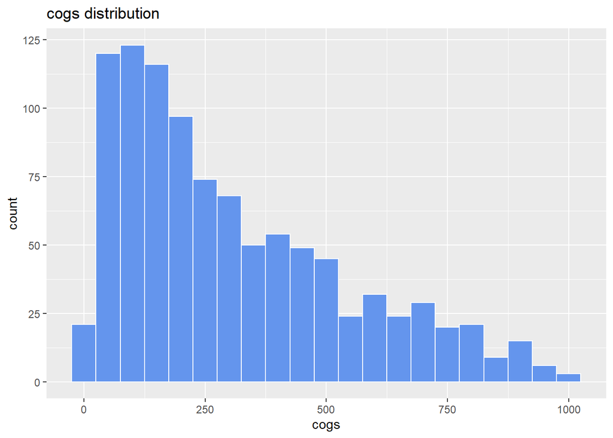

```r
# plot the histogram of cogs
ggplot(dataset, aes(x = cogs)) +
  geom_histogram(fill = "cornflowerblue",
                 color = "white",
                 binwidth = 50) +
  labs(title="cogs distribution",
       x = "cogs")
```

> From our histogram of cogs between 0 and 250 had the highest count.

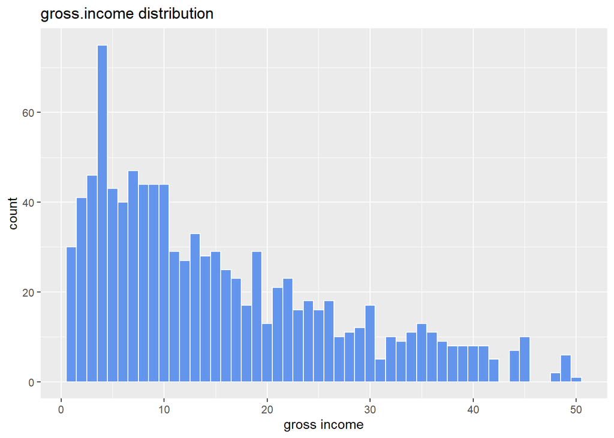

```r
# plot the histogram of gross.income
ggplot(dataset, aes(x = gross.income)) +
  geom_histogram(fill = "cornflowerblue",
                 color = "white",
                 binwidth = 1) +
  labs(title="gross.income distribution",
       x = "gross income")
```

> From our histogram of gross income it appears to be a large count from 0 to 10.

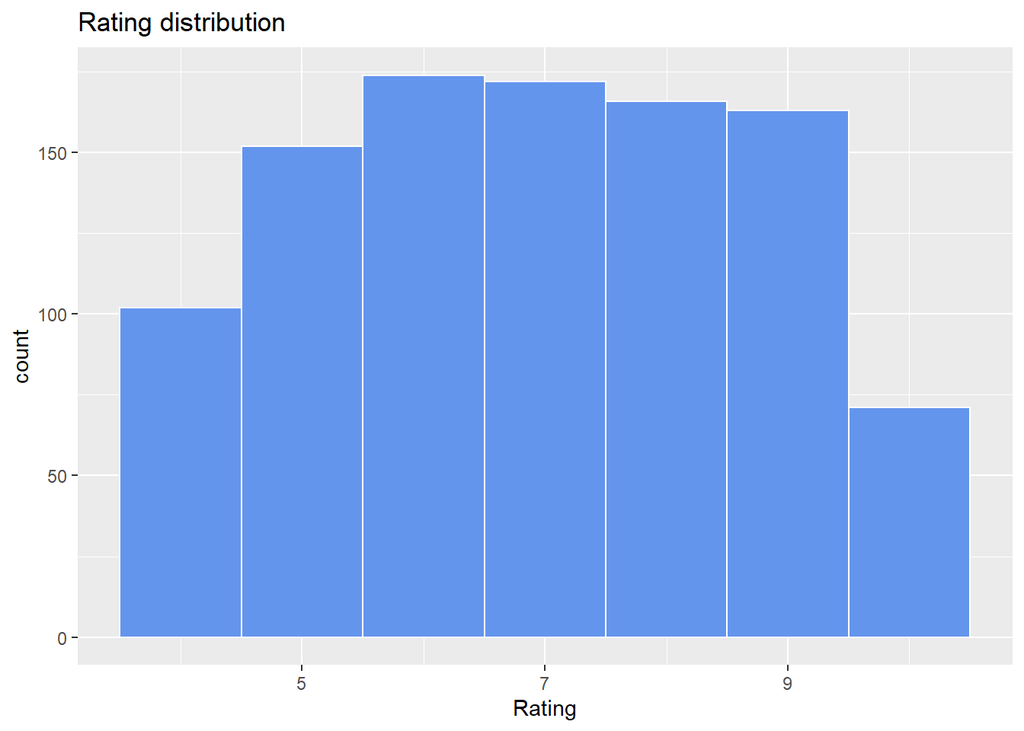

```r
# plot the histogram of Rating
ggplot(dataset, aes(x = Rating)) +
  geom_histogram(fill = "cornflowerblue",
                 color = "white",
                 binwidth = 1) +
  labs(title="Rating distribution",
       x = "Rating")
```

> From our histogram of Rating it appeared to have a high count between 6 and 7.

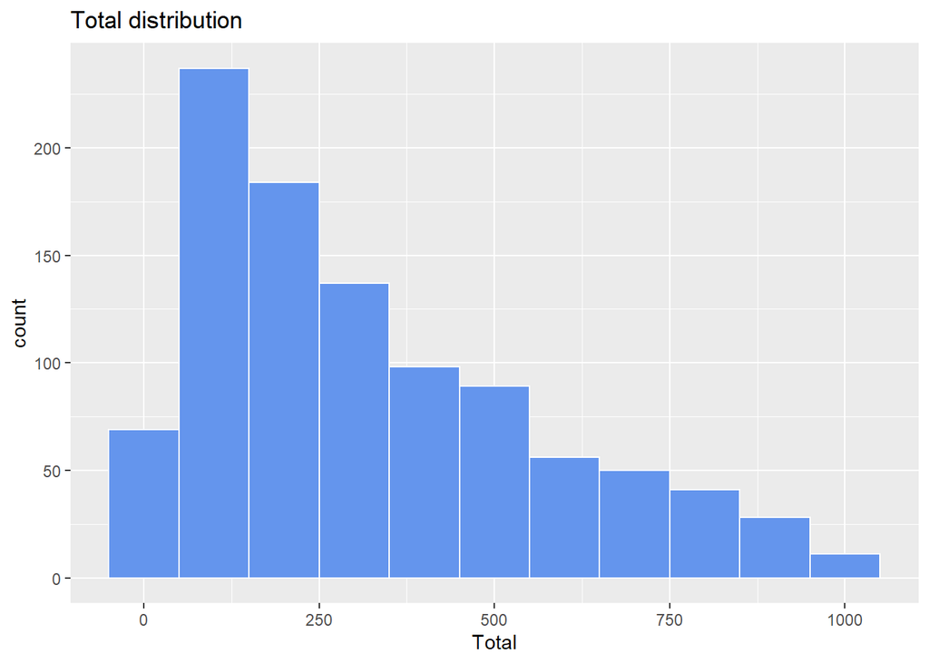

```r
# plot the histogram of Total
ggplot(dataset, aes(x = Total)) +
  geom_histogram(fill = "cornflowerblue",
                 color = "white",
                 binwidth = 100) +
  labs(title="Total distribution",
       x = "Total")
```

> Histogram of total distribution.

#### Bivariate Analysis

##### Grouped Bar Chart

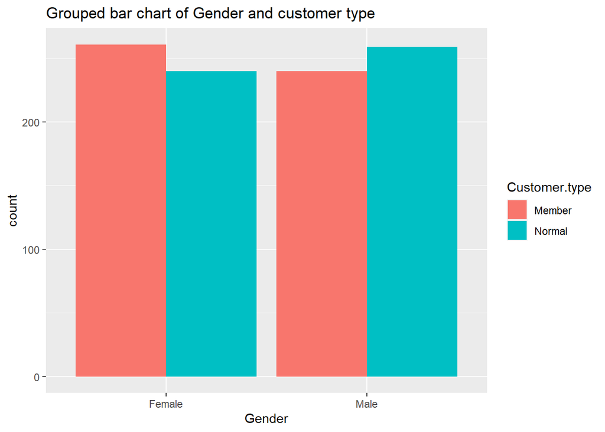

```r
# grouped bar plot of Gender and customer type
ggplot(dataset,
       aes(x = Gender,
           fill = Customer.type)) +
  geom_bar(position = position_dodge(preserve = "single")) +
  labs(title = "Grouped bar chart of Gender and customer type")
```

> From our barplot the Females had more member customers compared to normal customers while for the Male they had more Normal customers compared to member customers.

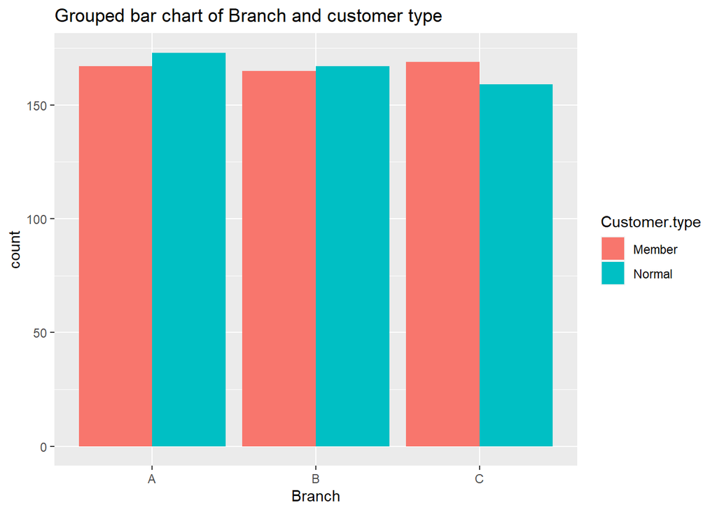

```r
# grouped bar plot of Branch and customer type
ggplot(dataset,
       aes(x = Branch,
           fill = Customer.type)) +
  geom_bar(position = position_dodge(preserve = "single")) +
  labs(title = "Grouped bar chart of Branch and customer type")
```

> From our barplot Branch A had more normal customers compared to member customers, branch B had slighlty more normal customers compared to member customers while for branch C had more member customers compared to the normal customers.

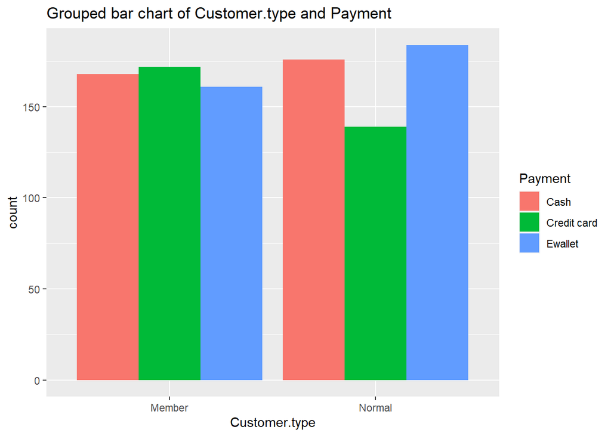

```r
# grouped bar plot of Customer.type and Payment
ggplot(dataset,
       aes(x = Customer.type,
           fill = Payment)) +
  geom_bar(position = position_dodge(preserve = "single")) +
  labs(title = "Grouped bar chart of Customer.type and Payment")
```

> From our Barplot the member customers prefered credit card payment, followed by cash and lastly Ewallet while for the Normal Customers they prefered Ewallet, followed by cash and least prefered Credit card.

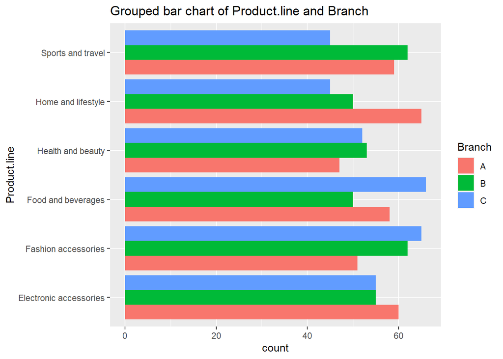

```r
# grouped bar plot of Product.line and Branch
ggplot(dataset,
       aes(x = Product.line,
           fill = Branch)) +
  geom_bar(position = position_dodge(preserve = "single")) +
  labs(title = "Grouped bar chart of Product.line and Branch") +
  coord_flip()
```

> From our barplot of product line vs Branch, for sports and travel products they were most sales from branch B , while for the home and lifestyle they had more sales in branch A, for health and beauty it had more sales from branch B, for food and beverages it had more sales in branch C , meanwhile for fashion and accessories it had more sales in branch C and lastly the electronic accessories had more sales in branch A.

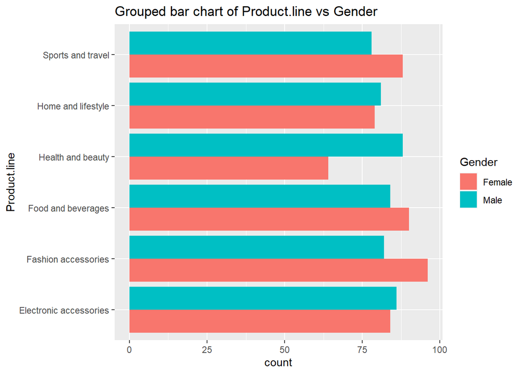

```r
# grouped bar plot of Product.line vs Gender
ggplot(dataset,
       aes(x = Product.line,
           fill = Gender)) +
  geom_bar(position = position_dodge(preserve = "single")) +
  labs(title = "Grouped bar chart of Product.line vs Gender") +
  coord_flip()
```

>From our barplot males purchased more electronic accessories, health and beauty and home and lifestyle. Females purchased more sports and travel products, food and beverages products and fashion accessories products.

### Scatterplot

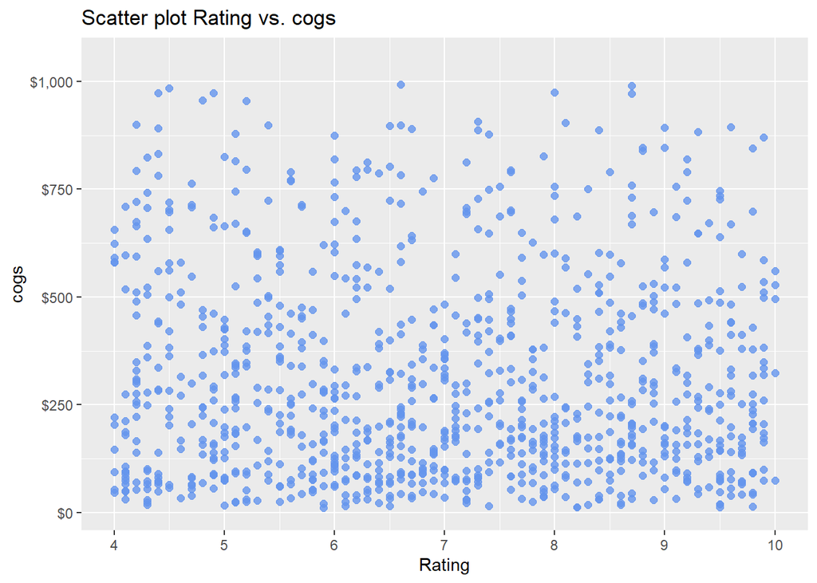

```r
# scatterplot of Rating vs. cogs
ggplot(dataset,
       aes(x = Rating,
           y = cogs)) +
  geom_point(color="cornflowerblue",
             size = 2,
             alpha=.8) +
  scale_y_continuous(label = scales::dollar,
                     limits = c(10, 1050)) +
  scale_x_continuous(breaks = seq(4,  10),
                     limits=c(4, 10)) +
  labs(x = "Rating",
       y = "cogs",
       title = "Scatter plot Rating vs. cogs")
```

> From our scatterplot cogs below 500 had the highest distribution at each product rating.

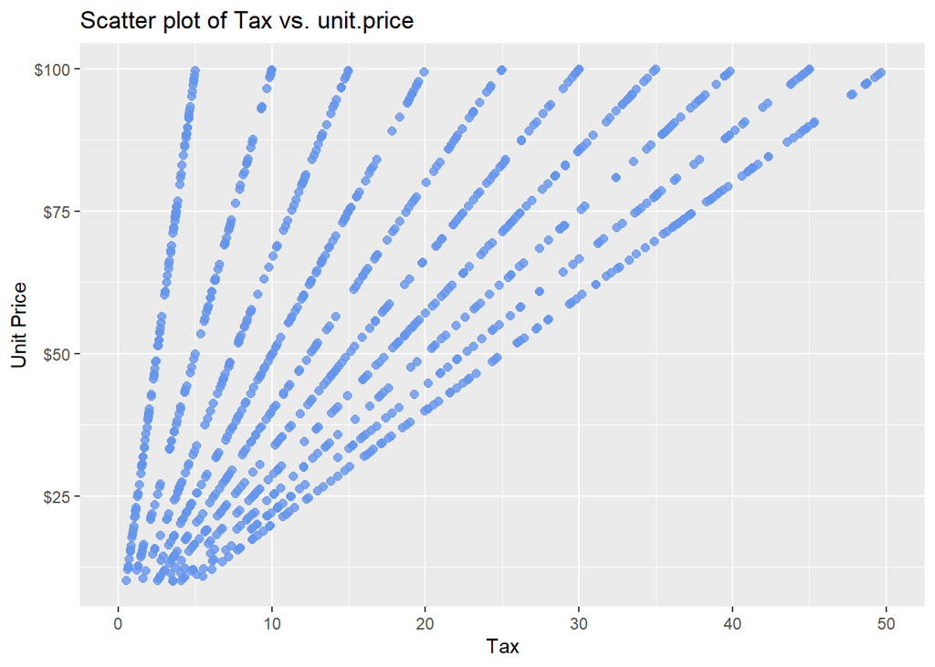

```r
# scatterplot of Tax vs. unit.price
ggplot(dataset,
       aes(x = Tax,
           y = Unit.price)) +
  geom_point(color="cornflowerblue",
             size = 2,
             alpha=.8) +
  scale_y_continuous(label = scales::dollar,
                     limits = c(10, 100)) +
  scale_x_continuous(breaks = seq(0,50, 10),
                     limits=c(0, 50)) +
  labs(x = "Tax",
       y = "Unit Price",
       title = "Scatter plot of Tax vs. unit.price")
```

> From our scatter plot of Tax vs Unit price as the unit price increases so does the tax rate.

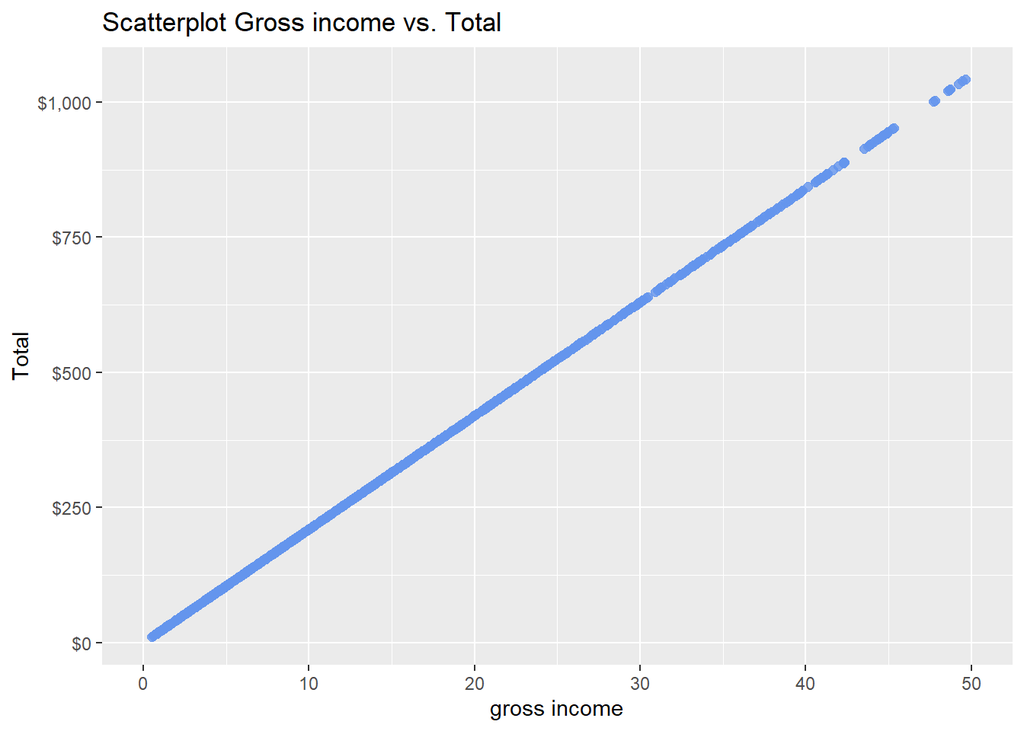

```r
# scatterplot of Gross income vs. Total
ggplot(dataset,
       aes(x = gross.income,
           y = Total)) +
  geom_point(color="cornflowerblue",
             size = 2,
             alpha=.8) +
  scale_y_continuous(label = scales::dollar,
                     limits = c(10, 1050)) +
  scale_x_continuous(breaks = seq(0,50, 10),
                     limits=c(0, 50)) +
  labs(x = "gross income",
       y = "Total",
       title = "Scatterplot Gross income vs. Total")
```

> From our scatterplot there appears to be a linear relationship between the total and gross income in >that as the gross income increases so does the total.

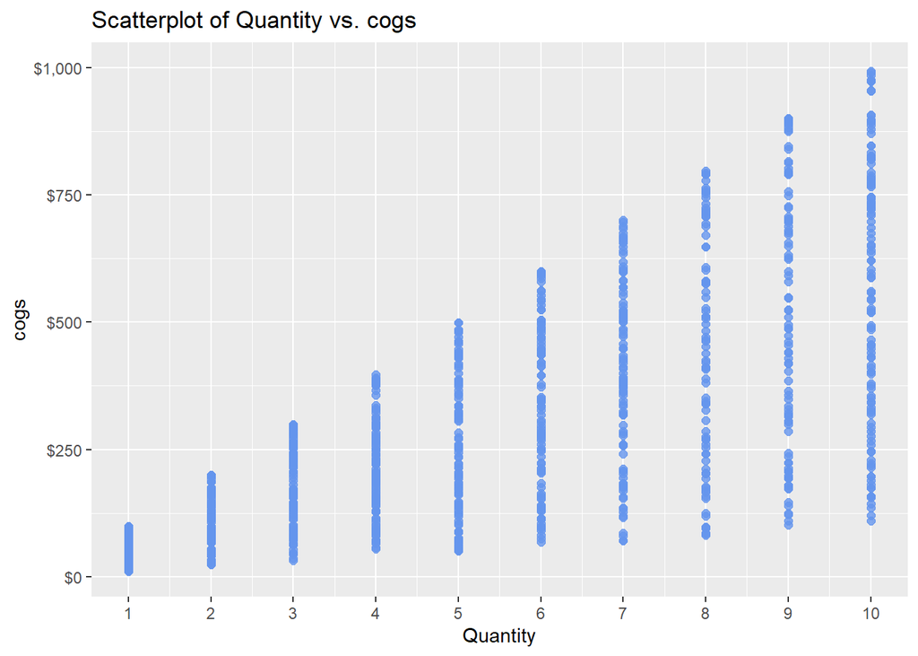

```r
# Scatterplot of Quantity vs. cogs
ggplot(dataset,
       aes(x = Quantity,
           y = cogs)) +
  geom_point(color="cornflowerblue",
             size = 2,
             alpha=.8) +
  scale_y_continuous(label = scales::dollar,
                     limits = c(10, 1000)) +
  scale_x_continuous(breaks = seq(0, 10),
                     limits=c(1, 10)) +
  labs(x = "Quantity",
       y = "cogs",
       title = "Scatterplot of Quantity vs. cogs")
```

> From our scatterplot as the quantity increases so does the values of the cost of goods sold increase.

## Implementing the Solution

### Principal Component Analysis

```r
library(Rtsne)
library(Rcpp)

# select the numerical columns exclude the categorical
df <- dataset[,c(6,8,12,14,16)]
head(df)
```

```
##   Unit.price     Tax   cogs gross.income    Total
## 1      74.69 26.1415 522.83      26.1415 548.9715
## 2      15.28  3.8200  76.40       3.8200  80.2200
## 3      46.33 16.2155 324.31      16.2155 340.5255
## 4      58.22 23.2880 465.76      23.2880 489.0480
## 5      86.31 30.2085 604.17      30.2085 634.3785
## 6      85.39 29.8865 597.73      29.8865 627.6165
```

```r
# pass df to the prcomp()
dataset.pca <- prcomp(df, center = TRUE, scale = TRUE)
summary(dataset.pca)
```

```
## Importance of components:
##                           PC1    PC2       PC3       PC4       PC5
## Standard deviation     2.1128 0.7321 2.582e-16 1.735e-16 1.036e-16
## Proportion of Variance 0.8928 0.1072 0.000e+00 0.000e+00 0.000e+00
## Cumulative Proportion  0.8928 1.0000 1.000e+00 1.000e+00 1.000e+00
```

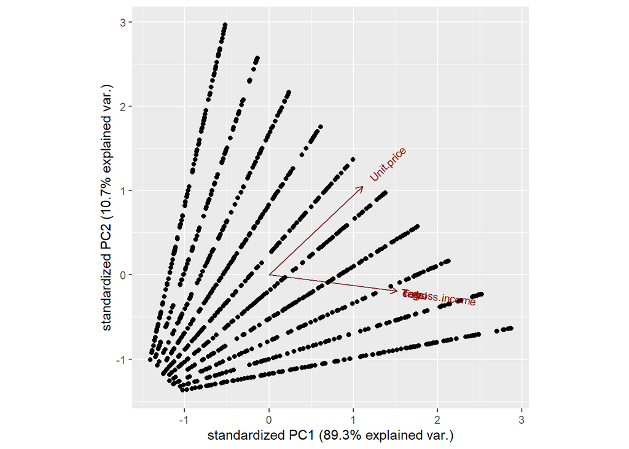

```r
# plot our pca.
library(devtools)
library(ggbiplot)
ggbiplot(dataset.pca)
```

> From the graph we see that the variables Unit.price, cogs and gross income contribute to PC1, with higher values in those variables moving the samples to the right on the plot.